# Risk Factor Analysis

## Outcome Variable

**Outcome Variable:** wasted

## Predictor Variables

**Intervention Variable:** earlybf

**Adjustment Set:**

unadjusted

## Stratifying Variables

The analysis was stratified on these variable(s):

- agecat
- studyid
- country

## Data Summary

| agecat | studyid | country | earlybf | wasted | n_cell | n | outcome_variable |
| --- | --- | --- | --- | --- | --- | --- | --- |
| Birth | ki0047075b-MAL-ED | BANGLADESH | 1 | 0 | 120 | 214 | wasted |
| Birth | ki0047075b-MAL-ED | BANGLADESH | 1 | 1 | 20 | 214 | wasted |
| Birth | ki0047075b-MAL-ED | BANGLADESH | 0 | 0 | 58 | 214 | wasted |
| Birth | ki0047075b-MAL-ED | BANGLADESH | 0 | 1 | 16 | 214 | wasted |
| Birth | ki0047075b-MAL-ED | BRAZIL | 1 | 0 | 25 | 62 | wasted |
| Birth | ki0047075b-MAL-ED | BRAZIL | 1 | 1 | 1 | 62 | wasted |
| Birth | ki0047075b-MAL-ED | BRAZIL | 0 | 0 | 35 | 62 | wasted |
| Birth | ki0047075b-MAL-ED | BRAZIL | 0 | 1 | 1 | 62 | wasted |
| Birth | ki0047075b-MAL-ED | INDIA | 1 | 0 | 27 | 44 | wasted |
| Birth | ki0047075b-MAL-ED | INDIA | 1 | 1 | 4 | 44 | wasted |
| Birth | ki0047075b-MAL-ED | INDIA | 0 | 0 | 12 | 44 | wasted |
| Birth | ki0047075b-MAL-ED | INDIA | 0 | 1 | 1 | 44 | wasted |
| Birth | ki0047075b-MAL-ED | NEPAL | 1 | 0 | 13 | 26 | wasted |
| Birth | ki0047075b-MAL-ED | NEPAL | 1 | 1 | 1 | 26 | wasted |
| Birth | ki0047075b-MAL-ED | NEPAL | 0 | 0 | 11 | 26 | wasted |
| Birth | ki0047075b-MAL-ED | NEPAL | 0 | 1 | 1 | 26 | wasted |
| Birth | ki0047075b-MAL-ED | PERU | 1 | 0 | 169 | 228 | wasted |
| Birth | ki0047075b-MAL-ED | PERU | 1 | 1 | 3 | 228 | wasted |
| Birth | ki0047075b-MAL-ED | PERU | 0 | 0 | 54 | 228 | wasted |
| Birth | ki0047075b-MAL-ED | PERU | 0 | 1 | 2 | 228 | wasted |
| Birth | ki0047075b-MAL-ED | SOUTH AFRICA | 1 | 0 | 64 | 110 | wasted |
| Birth | ki0047075b-MAL-ED | SOUTH AFRICA | 1 | 1 | 5 | 110 | wasted |
| Birth | ki0047075b-MAL-ED | SOUTH AFRICA | 0 | 0 | 36 | 110 | wasted |
| Birth | ki0047075b-MAL-ED | SOUTH AFRICA | 0 | 1 | 5 | 110 | wasted |
| Birth | ki0047075b-MAL-ED | TANZANIA, UNITED REPUBLIC OF | 1 | 0 | 102 | 115 | wasted |
| Birth | ki0047075b-MAL-ED | TANZANIA, UNITED REPUBLIC OF | 1 | 1 | 1 | 115 | wasted |
| Birth | ki0047075b-MAL-ED | TANZANIA, UNITED REPUBLIC OF | 0 | 0 | 12 | 115 | wasted |
| Birth | ki0047075b-MAL-ED | TANZANIA, UNITED REPUBLIC OF | 0 | 1 | 0 | 115 | wasted |
| Birth | ki1000109-EE | PAKISTAN | 1 | 0 | 34 | 170 | wasted |
| Birth | ki1000109-EE | PAKISTAN | 1 | 1 | 2 | 170 | wasted |

[output cut: 134 more lines]

The following strata were considered:

- agecat: 24 months, studyid: ki0047075b-MAL-ED, country: BANGLADESH
- agecat: 24 months, studyid: ki0047075b-MAL-ED, country: BRAZIL
- agecat: 24 months, studyid: ki0047075b-MAL-ED, country: INDIA
- agecat: 24 months, studyid: ki0047075b-MAL-ED, country: NEPAL
- agecat: 24 months, studyid: ki0047075b-MAL-ED, country: PERU
- agecat: 24 months, studyid: ki0047075b-MAL-ED, country: SOUTH AFRICA
- agecat: 24 months, studyid: ki0047075b-MAL-ED, country: TANZANIA, UNITED REPUBLIC OF
- agecat: 24 months, studyid: ki1000109-EE, country: PAKISTAN
- agecat: 24 months, studyid: ki1017093c-NIH-Crypto, country: BANGLADESH
- agecat: 24 months, studyid: ki1113344-GMS-Nepal, country: NEPAL
- agecat: 24 months, studyid: ki1126311-ZVITAMBO, country: ZIMBABWE
- agecat: 24 months, studyid: kiGH5241-JiVitA-3, country: BANGLADESH
- agecat: 24 months, studyid: kiGH5241-JiVitA-4, country: BANGLADESH
- agecat: 6 months, studyid: ki0047075b-MAL-ED, country: BANGLADESH
- agecat: 6 months, studyid: ki0047075b-MAL-ED, country: BRAZIL
- agecat: 6 months, studyid: ki0047075b-MAL-ED, country: INDIA
- agecat: 6 months, studyid: ki0047075b-MAL-ED, country: NEPAL
- agecat: 6 months, studyid: ki0047075b-MAL-ED, country: PERU
- agecat: 6 months, studyid: ki0047075b-MAL-ED, country: SOUTH AFRICA
- agecat: 6 months, studyid: ki0047075b-MAL-ED, country: TANZANIA, UNITED REPUBLIC OF
- agecat: 6 months, studyid: ki1000109-EE, country: PAKISTAN
- agecat: 6 months, studyid: ki1000304b-SAS-CompFeed, country: INDIA
- agecat: 6 months, studyid: ki1017093c-NIH-Crypto, country: BANGLADESH
- agecat: 6 months, studyid: ki1113344-GMS-Nepal, country: NEPAL
- agecat: 6 months, studyid: ki1126311-ZVITAMBO, country: ZIMBABWE
- agecat: 6 months, studyid: kiGH5241-JiVitA-3, country: BANGLADESH
- agecat: 6 months, studyid: kiGH5241-JiVitA-4, country: BANGLADESH
- agecat: Birth, studyid: ki0047075b-MAL-ED, country: BANGLADESH
- agecat: Birth, studyid: ki0047075b-MAL-ED, country: BRAZIL
- agecat: Birth, studyid: ki0047075b-MAL-ED, country: INDIA
- agecat: Birth, studyid: ki0047075b-MAL-ED, country: NEPAL
- agecat: Birth, studyid: ki0047075b-MAL-ED, country: PERU
- agecat: Birth, studyid: ki0047075b-MAL-ED, country: SOUTH AFRICA
- agecat: Birth, studyid: ki0047075b-MAL-ED, country: TANZANIA, UNITED REPUBLIC OF
- agecat: Birth, studyid: ki1000109-EE, country: PAKISTAN
- agecat: Birth, studyid: ki1000304b-SAS-CompFeed, country: INDIA
- agecat: Birth, studyid: ki1017093c-NIH-Crypto, country: BANGLADESH
- agecat: Birth, studyid: ki1113344-GMS-Nepal, country: NEPAL
- agecat: Birth, studyid: ki1126311-ZVITAMBO, country: ZIMBABWE
- agecat: Birth, studyid: kiGH5241-JiVitA-3, country: BANGLADESH
- agecat: Birth, studyid: kiGH5241-JiVitA-4, country: BANGLADESH

### Dropped Strata

Some strata were dropped due to rare outcomes:

- agecat: Birth, studyid: ki0047075b-MAL-ED, country: BRAZIL
- agecat: Birth, studyid: ki0047075b-MAL-ED, country: INDIA
- agecat: Birth, studyid: ki0047075b-MAL-ED, country: NEPAL
- agecat: Birth, studyid: ki0047075b-MAL-ED, country: PERU
- agecat: Birth, studyid: ki0047075b-MAL-ED, country: TANZANIA, UNITED REPUBLIC OF
- agecat: Birth, studyid: ki1000109-EE, country: PAKISTAN
- agecat: 6 months, studyid: ki0047075b-MAL-ED, country: BANGLADESH
- agecat: 6 months, studyid: ki0047075b-MAL-ED, country: BRAZIL
- agecat: 6 months, studyid: ki0047075b-MAL-ED, country: NEPAL
- agecat: 6 months, studyid: ki0047075b-MAL-ED, country: PERU
- agecat: 6 months, studyid: ki0047075b-MAL-ED, country: SOUTH AFRICA
- agecat: 6 months, studyid: ki0047075b-MAL-ED, country: TANZANIA, UNITED REPUBLIC OF
- agecat: 6 months, studyid: ki1017093c-NIH-Crypto, country: BANGLADESH
- agecat: 24 months, studyid: ki0047075b-MAL-ED, country: BRAZIL
- agecat: 24 months, studyid: ki0047075b-MAL-ED, country: NEPAL
- agecat: 24 months, studyid: ki0047075b-MAL-ED, country: PERU
- agecat: 24 months, studyid: ki0047075b-MAL-ED, country: SOUTH AFRICA
- agecat: 24 months, studyid: ki0047075b-MAL-ED, country: TANZANIA, UNITED REPUBLIC OF
- agecat: 24 months, studyid: ki1000109-EE, country: PAKISTAN
- agecat: 24 months, studyid: ki1017093c-NIH-Crypto, country: BANGLADESH
- agecat: 24 months, studyid: kiGH5241-JiVitA-3, country: BANGLADESH

## Methods Detail

We’re interested in the causal parameters $E[Y_a]$ for all values of $a \in \mathcal{A}$. These parameters represent the mean outcome if, possibly contrary to fact, we intervened to set all units to have $A=a$. Under the randomization and positivity assumptions, these are identified by the statistical parameters $\psi_a=E_W[E_{Y|A,W}(Y|A=a,W)]$. In addition, we’re interested in the mean of $Y$, $E[Y]$ under no intervention (the observed mean). We will estimate these parameters by using SuperLearner to fit the relevant likelihood factors – $E_{Y|A,W}(Y|A=a,W)$ and $p(A=a|W)$, and then updating our likelihood fit using a joint TMLE.

For unadjusted analyses ($W=\{\}$), initial likelihoods were estimated using Lrnr_glm to estimate the simple $E(Y|A)$ and Lrnr_mean to estimate $p(A)$. For adjusted analyses, a small library containing Lrnr_glmnet, Lrnr_xgboost, and Lrnr_mean was used.

Having estimated these parameters, we will then use the delta method to estimate relative risks and attributable risks relative to a prespecified baseline level of $A$.

# Results Detail

## Results Plots

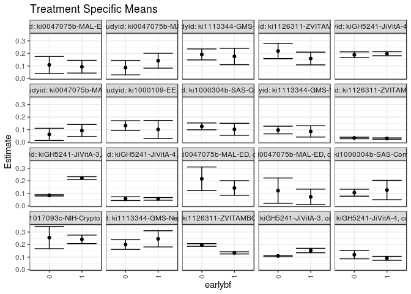

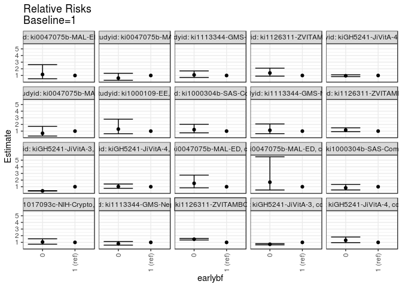

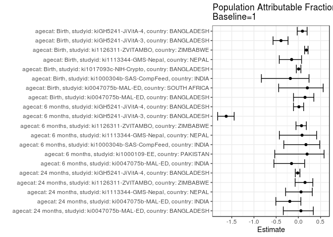

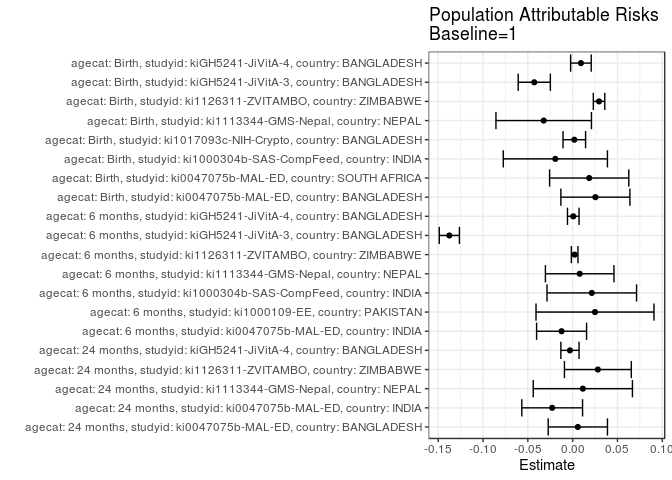

## Results Table

### Parameter: TSM

| agecat | studyid | country | intervention_level | baseline_level | estimate | ci_lower | ci_upper |
| --- | --- | --- | --- | --- | --- | --- | --- |
| Birth | ki0047075b-MAL-ED | BANGLADESH | 1 | NA | 0.1428571 | 0.0847568 | 0.2009575 |
| Birth | ki0047075b-MAL-ED | BANGLADESH | 0 | NA | 0.2162162 | 0.1222024 | 0.3102300 |
| Birth | ki0047075b-MAL-ED | SOUTH AFRICA | 1 | NA | 0.0724638 | 0.0110123 | 0.1339153 |
| Birth | ki0047075b-MAL-ED | SOUTH AFRICA | 0 | NA | 0.1219512 | 0.0213295 | 0.2225729 |
| Birth | ki1000304b-SAS-CompFeed | INDIA | 1 | NA | 0.1265823 | 0.0495234 | 0.2036412 |
| Birth | ki1000304b-SAS-CompFeed | INDIA | 0 | NA | 0.1057402 | 0.0779666 | 0.1335138 |
| Birth | ki1017093c-NIH-Crypto | BANGLADESH | 1 | NA | 0.2414356 | 0.2075338 | 0.2753373 |
| Birth | ki1017093c-NIH-Crypto | BANGLADESH | 0 | NA | 0.2553191 | 0.1671091 | 0.3435292 |
| Birth | ki1113344-GMS-Nepal | NEPAL | 1 | NA | 0.2456140 | 0.1810420 | 0.3101860 |
| Birth | ki1113344-GMS-Nepal | NEPAL | 0 | NA | 0.2000000 | 0.1614828 | 0.2385172 |
| Birth | ki1126311-ZVITAMBO | ZIMBABWE | 1 | NA | 0.1338326 | 0.1253174 | 0.1423478 |
| Birth | ki1126311-ZVITAMBO | ZIMBABWE | 0 | NA | 0.1969471 | 0.1863119 | 0.2075823 |
| Birth | kiGH5241-JiVitA-3 | BANGLADESH | 1 | NA | 0.1523810 | 0.1348322 | 0.1699298 |
| Birth | kiGH5241-JiVitA-3 | BANGLADESH | 0 | NA | 0.1093172 | 0.1040620 | 0.1145723 |
| Birth | kiGH5241-JiVitA-4 | BANGLADESH | 1 | NA | 0.0905172 | 0.0749442 | 0.1060903 |
| Birth | kiGH5241-JiVitA-4 | BANGLADESH | 0 | NA | 0.1191710 | 0.0865584 | 0.1517835 |
| 6 months | ki0047075b-MAL-ED | INDIA | 1 | NA | 0.0928571 | 0.0446788 | 0.1410355 |
| 6 months | ki0047075b-MAL-ED | INDIA | 0 | NA | 0.0625000 | 0.0139756 | 0.1110244 |
| 6 months | ki1000109-EE | PAKISTAN | 1 | NA | 0.1014493 | 0.0301120 | 0.1727866 |
| 6 months | ki1000109-EE | PAKISTAN | 0 | NA | 0.1322034 | 0.0934986 | 0.1709082 |
| 6 months | ki1000304b-SAS-CompFeed | INDIA | 1 | NA | 0.1030928 | 0.0556218 | 0.1505638 |
| 6 months | ki1000304b-SAS-CompFeed | INDIA | 0 | NA | 0.1261116 | 0.0987820 | 0.1534411 |
| 6 months | ki1113344-GMS-Nepal | NEPAL | 1 | NA | 0.0860927 | 0.0413091 | 0.1308763 |
| 6 months | ki1113344-GMS-Nepal | NEPAL | 0 | NA | 0.0972222 | 0.0665888 | 0.1278556 |
| 6 months | ki1126311-ZVITAMBO | ZIMBABWE | 1 | NA | 0.0292743 | 0.0240918 | 0.0344568 |
| 6 months | ki1126311-ZVITAMBO | ZIMBABWE | 0 | NA | 0.0341170 | 0.0280923 | 0.0401417 |
| 6 months | kiGH5241-JiVitA-3 | BANGLADESH | 1 | NA | 0.2222222 | 0.2115818 | 0.2328627 |
| 6 months | kiGH5241-JiVitA-3 | BANGLADESH | 0 | NA | 0.0843683 | 0.0794631 | 0.0892735 |
| 6 months | kiGH5241-JiVitA-4 | BANGLADESH | 1 | NA | 0.0562197 | 0.0456225 | 0.0668169 |
| 6 months | kiGH5241-JiVitA-4 | BANGLADESH | 0 | NA | 0.0581128 | 0.0431483 | 0.0730773 |
| 24 months | ki0047075b-MAL-ED | BANGLADESH | 1 | NA | 0.0937500 | 0.0431344 | 0.1443656 |
| 24 months | ki0047075b-MAL-ED | BANGLADESH | 0 | NA | 0.1084337 | 0.0413836 | 0.1754839 |
| 24 months | ki0047075b-MAL-ED | INDIA | 1 | NA | 0.1417910 | 0.0825974 | 0.2009847 |
| 24 months | ki0047075b-MAL-ED | INDIA | 0 | NA | 0.0860215 | 0.0289083 | 0.1431348 |
| 24 months | ki1113344-GMS-Nepal | NEPAL | 1 | NA | 0.1755725 | 0.1103486 | 0.2407964 |
| 24 months | ki1113344-GMS-Nepal | NEPAL | 0 | NA | 0.1916933 | 0.1480360 | 0.2353506 |
| 24 months | ki1126311-ZVITAMBO | ZIMBABWE | 1 | NA | 0.1592040 | 0.1085579 | 0.2098501 |
| 24 months | ki1126311-ZVITAMBO | ZIMBABWE | 0 | NA | 0.2191011 | 0.1582552 | 0.2799470 |
| 24 months | kiGH5241-JiVitA-4 | BANGLADESH | 1 | NA | 0.1972946 | 0.1812292 | 0.2133601 |
| 24 months | kiGH5241-JiVitA-4 | BANGLADESH | 0 | NA | 0.1889671 | 0.1658292 | 0.2121051 |

### Parameter: E(Y)

| agecat | studyid | country | intervention_level | baseline_level | estimate | ci_lower | ci_upper |
| --- | --- | --- | --- | --- | --- | --- | --- |
| Birth | ki0047075b-MAL-ED | BANGLADESH | NA | NA | 0.1682243 | 0.1179894 | 0.2184592 |
| Birth | ki0047075b-MAL-ED | SOUTH AFRICA | NA | NA | 0.0909091 | 0.0369404 | 0.1448778 |
| Birth | ki1000304b-SAS-CompFeed | INDIA | NA | NA | 0.1072761 | 0.0774575 | 0.1370947 |
| Birth | ki1017093c-NIH-Crypto | BANGLADESH | NA | NA | 0.2432815 | 0.2116319 | 0.2749310 |
| Birth | ki1113344-GMS-Nepal | NEPAL | NA | NA | 0.2133106 | 0.1801152 | 0.2465060 |
| Birth | ki1126311-ZVITAMBO | ZIMBABWE | NA | NA | 0.1632795 | 0.1565278 | 0.1700311 |
| Birth | kiGH5241-JiVitA-3 | BANGLADESH | NA | NA | 0.1095692 | 0.1044330 | 0.1147054 |
| Birth | kiGH5241-JiVitA-4 | BANGLADESH | NA | NA | 0.0997496 | 0.0843744 | 0.1151247 |
| 6 months | ki0047075b-MAL-ED | INDIA | NA | NA | 0.0805085 | 0.0457221 | 0.1152948 |
| 6 months | ki1000109-EE | PAKISTAN | NA | NA | 0.1263736 | 0.0921925 | 0.1605547 |
| 6 months | ki1000304b-SAS-CompFeed | INDIA | NA | NA | 0.1244378 | 0.0992652 | 0.1496104 |
| 6 months | ki1113344-GMS-Nepal | NEPAL | NA | NA | 0.0939335 | 0.0686141 | 0.1192529 |
| 6 months | ki1126311-ZVITAMBO | ZIMBABWE | NA | NA | 0.0315107 | 0.0275707 | 0.0354506 |
| 6 months | kiGH5241-JiVitA-3 | BANGLADESH | NA | NA | 0.0846640 | 0.0798626 | 0.0894653 |
| 6 months | kiGH5241-JiVitA-4 | BANGLADESH | NA | NA | 0.0569005 | 0.0480577 | 0.0657432 |
| 24 months | ki0047075b-MAL-ED | BANGLADESH | NA | NA | 0.0995261 | 0.0590366 | 0.1400156 |
| 24 months | ki0047075b-MAL-ED | INDIA | NA | NA | 0.1189427 | 0.0767376 | 0.1611478 |
| 24 months | ki1113344-GMS-Nepal | NEPAL | NA | NA | 0.1869369 | 0.1506328 | 0.2232411 |
| 24 months | ki1126311-ZVITAMBO | ZIMBABWE | NA | NA | 0.1873351 | 0.1480011 | 0.2266690 |
| 24 months | kiGH5241-JiVitA-4 | BANGLADESH | NA | NA | 0.1942978 | 0.1810880 | 0.2075076 |

### Parameter: RR

| agecat | studyid | country | intervention_level | baseline_level | estimate | ci_lower | ci_upper |
| --- | --- | --- | --- | --- | --- | --- | --- |
| Birth | ki0047075b-MAL-ED | BANGLADESH | 1 | 1 | 1.0000000 | 1.0000000 | 1.0000000 |
| Birth | ki0047075b-MAL-ED | BANGLADESH | 0 | 1 | 1.5135135 | 0.8344854 | 2.7450727 |
| Birth | ki0047075b-MAL-ED | SOUTH AFRICA | 1 | 1 | 1.0000000 | 1.0000000 | 1.0000000 |
| Birth | ki0047075b-MAL-ED | SOUTH AFRICA | 0 | 1 | 1.6829268 | 0.5154797 | 5.4943827 |
| Birth | ki1000304b-SAS-CompFeed | INDIA | 1 | 1 | 1.0000000 | 1.0000000 | 1.0000000 |
| Birth | ki1000304b-SAS-CompFeed | INDIA | 0 | 1 | 0.8353474 | 0.5199323 | 1.3421082 |
| Birth | ki1017093c-NIH-Crypto | BANGLADESH | 1 | 1 | 1.0000000 | 1.0000000 | 1.0000000 |
| Birth | ki1017093c-NIH-Crypto | BANGLADESH | 0 | 1 | 1.0575043 | 0.7283142 | 1.5354847 |
| Birth | ki1113344-GMS-Nepal | NEPAL | 1 | 1 | 1.0000000 | 1.0000000 | 1.0000000 |
| Birth | ki1113344-GMS-Nepal | NEPAL | 0 | 1 | 0.8142857 | 0.5878188 | 1.1280028 |
| Birth | ki1126311-ZVITAMBO | ZIMBABWE | 1 | 1 | 1.0000000 | 1.0000000 | 1.0000000 |
| Birth | ki1126311-ZVITAMBO | ZIMBABWE | 0 | 1 | 1.4715928 | 1.3537700 | 1.5996701 |
| Birth | kiGH5241-JiVitA-3 | BANGLADESH | 1 | 1 | 1.0000000 | 1.0000000 | 1.0000000 |
| Birth | kiGH5241-JiVitA-3 | BANGLADESH | 0 | 1 | 0.7173940 | 0.6327818 | 0.8133202 |
| Birth | kiGH5241-JiVitA-4 | BANGLADESH | 1 | 1 | 1.0000000 | 1.0000000 | 1.0000000 |
| Birth | kiGH5241-JiVitA-4 | BANGLADESH | 0 | 1 | 1.3165556 | 0.9602279 | 1.8051118 |
| 6 months | ki0047075b-MAL-ED | INDIA | 1 | 1 | 1.0000000 | 1.0000000 | 1.0000000 |
| 6 months | ki0047075b-MAL-ED | INDIA | 0 | 1 | 0.6730769 | 0.2645580 | 1.7124128 |
| 6 months | ki1000109-EE | PAKISTAN | 1 | 1 | 1.0000000 | 1.0000000 | 1.0000000 |
| 6 months | ki1000109-EE | PAKISTAN | 0 | 1 | 1.3031477 | 0.6084070 | 2.7912135 |
| 6 months | ki1000304b-SAS-CompFeed | INDIA | 1 | 1 | 1.0000000 | 1.0000000 | 1.0000000 |
| 6 months | ki1000304b-SAS-CompFeed | INDIA | 0 | 1 | 1.2232821 | 0.7390414 | 2.0248110 |
| 6 months | ki1113344-GMS-Nepal | NEPAL | 1 | 1 | 1.0000000 | 1.0000000 | 1.0000000 |
| 6 months | ki1113344-GMS-Nepal | NEPAL | 0 | 1 | 1.1292735 | 0.6147182 | 2.0745420 |
| 6 months | ki1126311-ZVITAMBO | ZIMBABWE | 1 | 1 | 1.0000000 | 1.0000000 | 1.0000000 |
| 6 months | ki1126311-ZVITAMBO | ZIMBABWE | 0 | 1 | 1.1654243 | 0.9075893 | 1.4965071 |
| 6 months | kiGH5241-JiVitA-3 | BANGLADESH | 1 | 1 | 1.0000000 | 1.0000000 | 1.0000000 |
| 6 months | kiGH5241-JiVitA-3 | BANGLADESH | 0 | 1 | 0.3796573 | 0.3526532 | 0.4087292 |
| 6 months | kiGH5241-JiVitA-4 | BANGLADESH | 1 | 1 | 1.0000000 | 1.0000000 | 1.0000000 |
| 6 months | kiGH5241-JiVitA-4 | BANGLADESH | 0 | 1 | 1.0336726 | 0.7562894 | 1.4127913 |
| 24 months | ki0047075b-MAL-ED | BANGLADESH | 1 | 1 | 1.0000000 | 1.0000000 | 1.0000000 |
| 24 months | ki0047075b-MAL-ED | BANGLADESH | 0 | 1 | 1.1566265 | 0.5089650 | 2.6284418 |
| 24 months | ki0047075b-MAL-ED | INDIA | 1 | 1 | 1.0000000 | 1.0000000 | 1.0000000 |
| 24 months | ki0047075b-MAL-ED | INDIA | 0 | 1 | 0.6066780 | 0.2769161 | 1.3291323 |
| 24 months | ki1113344-GMS-Nepal | NEPAL | 1 | 1 | 1.0000000 | 1.0000000 | 1.0000000 |
| 24 months | ki1113344-GMS-Nepal | NEPAL | 0 | 1 | 1.0918183 | 0.7061683 | 1.6880782 |
| 24 months | ki1126311-ZVITAMBO | ZIMBABWE | 1 | 1 | 1.0000000 | 1.0000000 | 1.0000000 |
| 24 months | ki1126311-ZVITAMBO | ZIMBABWE | 0 | 1 | 1.3762289 | 0.9021857 | 2.0993528 |
| 24 months | kiGH5241-JiVitA-4 | BANGLADESH | 1 | 1 | 1.0000000 | 1.0000000 | 1.0000000 |
| 24 months | kiGH5241-JiVitA-4 | BANGLADESH | 0 | 1 | 0.9577916 | 0.8266020 | 1.1098023 |

### Parameter: PAR

| agecat | studyid | country | intervention_level | baseline_level | estimate | ci_lower | ci_upper |
| --- | --- | --- | --- | --- | --- | --- | --- |
| Birth | ki0047075b-MAL-ED | BANGLADESH | 1 | NA | 0.0253672 | -0.0131356 | 0.0638699 |
| Birth | ki0047075b-MAL-ED | SOUTH AFRICA | 1 | NA | 0.0184453 | -0.0257292 | 0.0626198 |
| Birth | ki1000304b-SAS-CompFeed | INDIA | 1 | NA | -0.0193062 | -0.0774143 | 0.0388020 |
| Birth | ki1017093c-NIH-Crypto | BANGLADESH | 1 | NA | 0.0018459 | -0.0107233 | 0.0144151 |
| Birth | ki1113344-GMS-Nepal | NEPAL | 1 | NA | -0.0323035 | -0.0855769 | 0.0209700 |
| Birth | ki1126311-ZVITAMBO | ZIMBABWE | 1 | NA | 0.0294469 | 0.0230644 | 0.0358293 |
| Birth | kiGH5241-JiVitA-3 | BANGLADESH | 1 | NA | -0.0428118 | -0.0607469 | -0.0248766 |
| Birth | kiGH5241-JiVitA-4 | BANGLADESH | 1 | NA | 0.0092323 | -0.0022663 | 0.0207310 |
| 6 months | ki0047075b-MAL-ED | INDIA | 1 | NA | -0.0123487 | -0.0402294 | 0.0155320 |
| 6 months | ki1000109-EE | PAKISTAN | 1 | NA | 0.0249244 | -0.0408632 | 0.0907119 |
| 6 months | ki1000304b-SAS-CompFeed | INDIA | 1 | NA | 0.0213450 | -0.0286023 | 0.0712923 |
| 6 months | ki1113344-GMS-Nepal | NEPAL | 1 | NA | 0.0078407 | -0.0303869 | 0.0460684 |
| 6 months | ki1126311-ZVITAMBO | ZIMBABWE | 1 | NA | 0.0022364 | -0.0014340 | 0.0059067 |
| 6 months | kiGH5241-JiVitA-3 | BANGLADESH | 1 | NA | -0.1375583 | -0.1488080 | -0.1263085 |
| 6 months | kiGH5241-JiVitA-4 | BANGLADESH | 1 | NA | 0.0006808 | -0.0057796 | 0.0071411 |
| 24 months | ki0047075b-MAL-ED | BANGLADESH | 1 | NA | 0.0057761 | -0.0272847 | 0.0388368 |
| 24 months | ki0047075b-MAL-ED | INDIA | 1 | NA | -0.0228483 | -0.0567365 | 0.0110399 |
| 24 months | ki1113344-GMS-Nepal | NEPAL | 1 | NA | 0.0113644 | -0.0439692 | 0.0666980 |
| 24 months | ki1126311-ZVITAMBO | ZIMBABWE | 1 | NA | 0.0281311 | -0.0091717 | 0.0654339 |
| 24 months | kiGH5241-JiVitA-4 | BANGLADESH | 1 | NA | -0.0029968 | -0.0131480 | 0.0071543 |

### Parameter: PAF

| agecat | studyid | country | intervention_level | baseline_level | estimate | ci_lower | ci_upper |
| --- | --- | --- | --- | --- | --- | --- | --- |
| Birth | ki0047075b-MAL-ED | BANGLADESH | 1 | NA | 0.1507937 | -0.1080697 | 0.3491822 |
| Birth | ki0047075b-MAL-ED | SOUTH AFRICA | 1 | NA | 0.2028986 | -0.4432286 | 0.5597574 |
| Birth | ki1000304b-SAS-CompFeed | INDIA | 1 | NA | -0.1799670 | -0.8324442 | 0.2401831 |
| Birth | ki1017093c-NIH-Crypto | BANGLADESH | 1 | NA | 0.0075875 | -0.0454428 | 0.0579279 |
| Birth | ki1113344-GMS-Nepal | NEPAL | 1 | NA | -0.1514386 | -0.4298194 | 0.0727424 |
| Birth | ki1126311-ZVITAMBO | ZIMBABWE | 1 | NA | 0.1803463 | 0.1408206 | 0.2180538 |
| Birth | kiGH5241-JiVitA-3 | BANGLADESH | 1 | NA | -0.3907281 | -0.5700005 | -0.2319261 |
| Birth | kiGH5241-JiVitA-4 | BANGLADESH | 1 | NA | 0.0925552 | -0.0255085 | 0.1970265 |
| 6 months | ki0047075b-MAL-ED | INDIA | 1 | NA | -0.1533835 | -0.5504312 | 0.1419849 |
| 6 months | ki1000109-EE | PAKISTAN | 1 | NA | 0.1972275 | -0.5313880 | 0.5791767 |
| 6 months | ki1000304b-SAS-CompFeed | INDIA | 1 | NA | 0.1715315 | -0.3276061 | 0.4830093 |
| 6 months | ki1113344-GMS-Nepal | NEPAL | 1 | NA | 0.0834713 | -0.4280605 | 0.4117722 |
| 6 months | ki1126311-ZVITAMBO | ZIMBABWE | 1 | NA | 0.0709717 | -0.0527651 | 0.1801651 |
| 6 months | kiGH5241-JiVitA-3 | BANGLADESH | 1 | NA | -1.6247556 | -1.8169228 | -1.4456979 |
| 6 months | kiGH5241-JiVitA-4 | BANGLADESH | 1 | NA | 0.0119642 | -0.1082323 | 0.1191244 |
| 24 months | ki0047075b-MAL-ED | BANGLADESH | 1 | NA | 0.0580357 | -0.3393097 | 0.3374970 |
| 24 months | ki0047075b-MAL-ED | INDIA | 1 | NA | -0.1920951 | -0.5068616 | 0.0569202 |
| 24 months | ki1113344-GMS-Nepal | NEPAL | 1 | NA | 0.0607928 | -0.2869813 | 0.3145897 |
| 24 months | ki1126311-ZVITAMBO | ZIMBABWE | 1 | NA | 0.1501647 | -0.0722960 | 0.3264732 |
| 24 months | kiGH5241-JiVitA-4 | BANGLADESH | 1 | NA | -0.0154240 | -0.0691279 | 0.0355823 |